# Bayesian computational mixed models in R

Ben Bolker

24 June 2023

Licensed under the [Creative Commons attribution-noncommercial license](http://creativecommons.org/licenses/by-nc/3.0/). Please share & remix noncommercially, mentioning its origin.

## Why Bayes?

- philosophically satisfying
- addresses model complexity problems  
  (use regularizing or truly informative priors)
- accounts for all levels of uncertainty
- makes post-modeling inference easy

## Basic Bayes

Posterior probability $\propto$ likelihood $\times$ prior

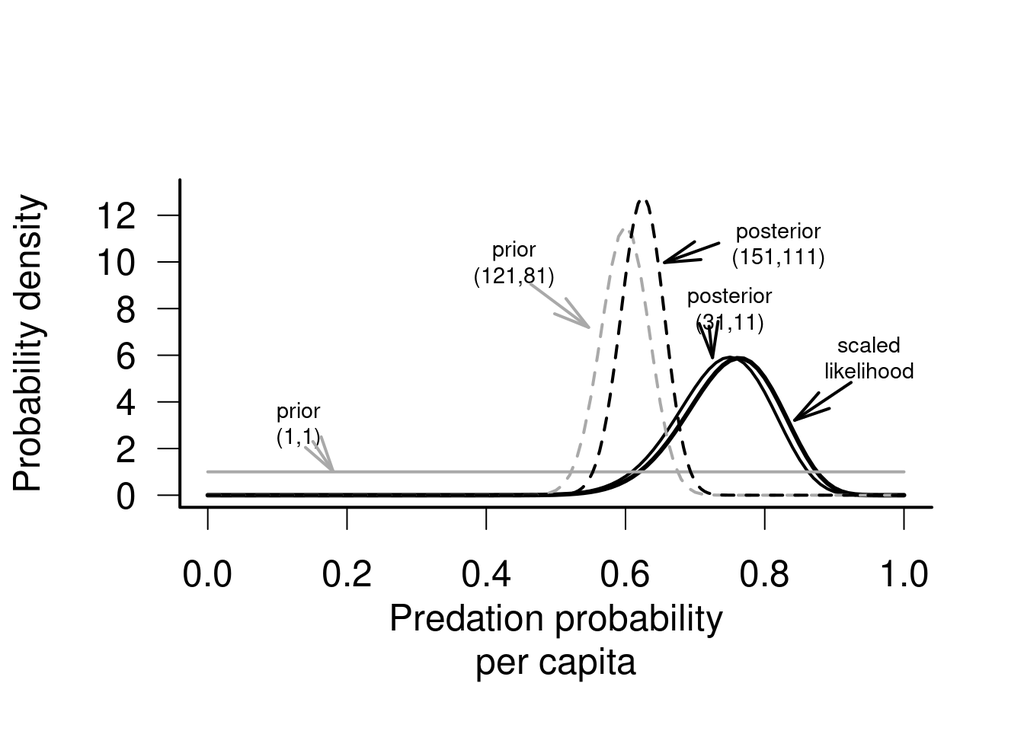

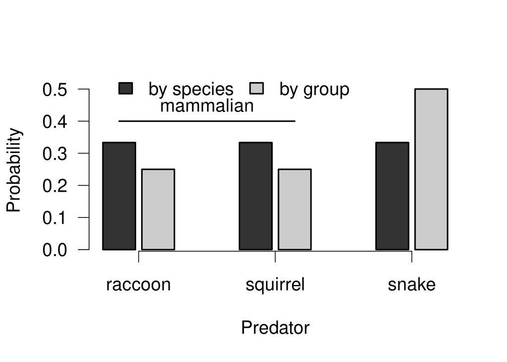

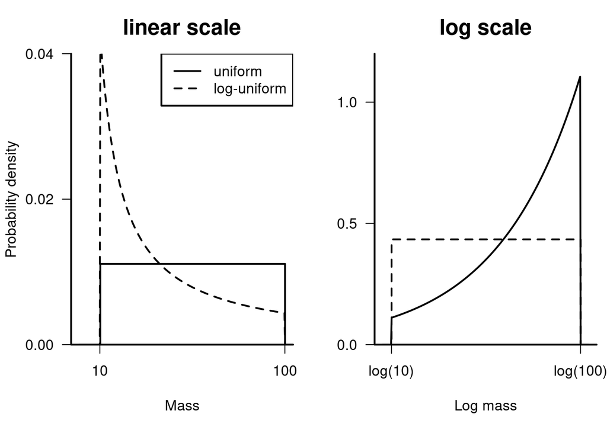

## Priors, continued

- continued debate over priors
- “uninformative” or “flat”: probably not really
- “conjugate”: mathematically/computationally convenient
- **regularizing** priors: neutral, but not completely uninformative
  - keeps model from misbehaving
  - **informative** priors: non-neutral, real information (Crome, Thomas, and Moore 1996, @McCarthy2007)
- simple ‘uninformative’ priors for variances etc. might not be (Gelman 2006)
- uniform priors are simple but problematic (Carpenter 2017)
- remember, scale of parameter matters!

## typical neutral/regularizing priors

- fixed-effect parameters (Greenland and Mansournia 2015)
  - typically Normal, mean 0, std dev 3–5
  - assume parameters are scaled or on log/logit scale
  - Student-$t$/Cauchy allow heavier tails
- variance parameters
  - Gamma(small shape): typical but problematic
  - Gamma(shape=2,$\lambda \to 0$): weakly regularizing (Chung et al. 2013) (`blme` package)
- correlation matrices
  - Wishart, inverse-Wishart: small shape parameters
  - LKJ or “onion” priors (Lewandowski, Kurowicka, and Joe 2009): `eta>1` makes extreme correlations less likely

## Sampling

Almost all modern Bayesian methods depend on stochastic sampling schemes

e.g.

- *conjugate sampling*: for easy cases where we can derive the posterior distribution
- *Gibbs sampling*: stepwise sampling of different model components
- *Metropolis-Hastings*: choose *candidate distribution* and accept/reject
- *Hamiltonian Monte Carlo*

## Metropolis-Hastings

- sampling parameter space
- start at a point (set of parameter values) $A$
  - pick a new point $B$ (from *candidate distribution*)
  - evaluate $P$= prior $\times$ likelihood
  - always accept if $P(B)$ better than $P(A)$
  - if $B$ is worse, accept with probability $P(B)/P(A)$
  - (extra term if candidate distribution is asymmetric)
  - generally converges to posterior distribution

## acceptance ratio

- candidate distribution too big: lots of rejection
- candidate distribution too small: lots of acceptance, but small moves
- either problem leads to inefficient sampling, highly correlated chains
- optimal acceptance $\approx 20\%$

## Hamiltonian MC

- start at a point
- simulate a particle moving along the surface with *random* momentum
- hard parts: finding the gradient, knowing when to stop (“No U-Turn Sampler”)

## Burn-in, adaptation and thinning

- *burn-in*: wait for chain to travel from starting point to highest posterior density region
- *adaptation*: use chain performance (acceptance/rejection) to tune candidate distribution
- *thinning*: if chain is correlated, subsample (e.g. down to 1000 samples)

## Multiple chains

- Best way of assessing convergence
- Can be run in parallel (different cores/machines)
- Start at widely dispersed points (but workable)
- Run until coverage of chains overlaps

## Diagnostics: tests of convergence

- Gelman-Rubin statistic (*potential scale reduction factor*: $R < 1.1$? 1.02?); needs multiple chains (Vats and Knudson 2018)
- effective sample size ($>500$)
- traceplot (should look like white noise)

## Tackling fitting/convergence problems

- strengthen priors (keep model from getting in trouble)
- simplify model
- reparameterize (?)
- run the model for longer (and thin correspondingly)

## Diagnostics: model adequacy

- plots of predictions
- posterior predictive distributions
- parameter correlations: `pairs(fitted,gap=0,pch=".")`

## Model goodness of fit (relative)

- leave-one-out cross-validation (`loo`)
- WAIC

## Inference

- samplers return a *matrix* of parameter values (values of each parameter for each sample)
- Posterior medians (or means)
- Quantile intervals (`quantile()`)
  - or *highest posterior density* intervals: (`coda::HPDinterval`, `emdbook::HPDregion`)

## Inference on functions of parameters

- e.g. CIs on predictions
- easy! compute whatever function you want

Carpenter, Bob. 2017. “Computational and Statistical Issues with Uniform Interval Priors.” *Statistical Modeling, Causal Inference, and Social Science*. http://andrewgelman.com/2017/11/28/computational-statistical-issues-uniform-interval-priors/.

Chung, Yeojin, Sophia Rabe-Hesketh, Vincent Dorie, Andrew Gelman, and Jingchen Liu. 2013. “A Nondegenerate Penalized Likelihood Estimator for Variance Parameters in Multilevel Models.” *Psychometrika*, 1–25. https://doi.org/10.1007/s11336-013-9328-2.

Crome, F. H. J., M. R. Thomas, and L. A. Moore. 1996. “A Novel Bayesian Approach to Assessing Impacts of Rain Forest Logging.” *Ecological Applications* 6: 1104–23.

Gelman, Andrew. 2006. “Prior Distributions for Variance Parameters in Hierarchical Models.” *Bayesian Analysis* 1 (3): 515–33. http://ba.stat.cmu.edu/journal/2006/vol01/issue03/gelman.pdf.

Greenland, Sander, and Mohammad Ali Mansournia. 2015. “Penalization, Bias Reduction, and Default Priors in Logistic and Related Categorical and Survival Regressions.” *Statistics in Medicine* 34 (23): 3133–43. https://doi.org/10.1002/sim.6537.

Lewandowski, Daniel, Dorota Kurowicka, and Harry Joe. 2009. “Generating Random Correlation Matrices Based on Vines and Extended Onion Method.” *Journal of Multivariate Analysis* 100 (9): 1989–2001. https://doi.org/10.1016/j.jmva.2009.04.008.

McCarthy, M. 2007. *Bayesian Methods for Ecology*. Cambridge, England: Cambridge University Press.

Vats, Dootika, and Christina Knudson. 2018. “Revisiting the Gelman-Rubin Diagnostic.” *arXiv:1812.09384 [Stat]*, December. http://arxiv.org/abs/1812.09384.